# 02_Data Cleaning

Simon Jean

2025-01-29

## Chargement de l’environnement

```
## here() starts at C:/Users/jean/OneDrive/Desktop/Teaching/AgroParisTech/Master EEET/M1/Economie écologique/intro_data_analysis
```

## Chargement des données

*Note* : pour ouvrir un “code chunk”, vous pouvez taper `Ctrl + Alt + i`

On charge les données :

```r
data_ = readxl::read_xlsx(here("data", "raw", "baie_somme_2025.xlsx"))

head(data_)
```

```
## # A tibble: 6 × 16
##   Horodateur          `Lieu de l'entretien` `Jour de l'entretien`
##   <dttm>              <chr>                 <dttm>
## 1 2025-01-13 14:38:18 Hourdel               2025-01-13 00:00:00
## 2 2025-01-13 14:48:03 Hourdel               2025-01-13 00:00:00
## 3 2025-01-13 15:06:42 <NA>                  NA
## 4 2025-01-13 15:13:54 <NA>                  NA
## 5 2025-01-13 15:26:11 <NA>                  NA
## 6 2025-01-13 15:34:16 Pointe                2025-01-13 00:00:00
## # ℹ 13 more variables: `Heure de l'entretien` <dttm>,
## #   `Caractéristique de la personne interviewée` <chr>,
## #   `Age approximatif` <chr>,
## #   `Lieu de résidence de la personne interviewée` <chr>,
## #   `Activité de loisir de la personne interrogée :` <chr>,
## #   `Activité professionnelle de la personne interrogée :` <chr>,
## #   `Q1 : Connaissez-vous le nom des espèces de phoques qui sont présentes dans la baie de Somme ? (Si oui préciser les espèces, Si ne sait pas, donner les deux noms des espèces (phoque gris et phoque veau-marin))` <chr>, …
```

## Diagnostic

- On va regarder déja la structure des données et le taux de complétude des données
- On va ensuite regarder comment standardiser les noms de variables, les réponses aux questions (souvent imparfaites), assigner le bon format etc.

## Exploration des variables

```
##  POSIXct[1:218], format: "2025-01-13 14:38:18" "2025-01-13 14:48:03" "2025-01-13 15:06:42" ...
```

```
##  chr [1:218] "Employé" "Employé" "Retraite" "Retraité" "Retraite" ...
```

```
##  chr [1:218] "Il faut laisser la nature évoluer librement, La surfréquentation peut générer des dérangements pour la nature" ...
```

```
##  [1] "Horodateur"
##  [2] "Lieu de l'entretien"
##  [3] "Jour de l'entretien"
##  [4] "Heure de l'entretien"
##  [5] "Caractéristique de la personne interviewée"
##  [6] "Age approximatif"
##  [7] "Lieu de résidence de la personne interviewée"
##  [8] "Activité de loisir de la personne interrogée :"
##  [9] "Activité professionnelle de la personne interrogée :"
## [10] "Q1 : Connaissez-vous le nom des espèces de phoques qui sont présentes dans la baie de Somme ? (Si oui préciser les espèces, Si ne sait pas, donner les deux noms des espèces (phoque gris et phoque veau-marin))"
## [11] "Q2 : Savez-vous combien il y a de phoque gris et de phoque veau-marin dans la baie de Somme ?"
## [12] "Q3 : Avez-vous déjà vu des phoques dans la baie"
## [13] "Q4 : Est-ce qu’ils vous dérangent dans vos activités de loisir ou professionnelle ? Pourquoi ?"
## [14] "Q5 : A quoi assimilez vous le phoque (2 choix max) ?"
## [15] "Q6 :  Pouvez-vous me dire si vous êtes d’accord avec les affirmations suivantes (cocher lorsque accord) ?"
## [16] "Avez-vous des suggestions concernant cette question des phoques dans la Baie de Somme ?"
```

- On a plusieurs informations sur les formats :
  - `POSIT`: données temporelles formatées en date
  - `chr` : données “character” i.e. données textuelles, sans notion d’ordre etc
- Pour certaines variables on va vouloir passer de données textuelles à des données catégorielles, c’est à dire des données textuelles avec différents niveaux
- Pour certaines questions à choix multiple, les réponses sont collées entre elles :
  - Il va falloir réfléchir à comment les extraire
  - Et à comment les exploiter
- Les noms de colonnes ne sont pas pratiques à utiliser : on va les renommer

```r
colnames(data_) = c("date", "lieu", "jour", "heure", "genre",
                    "classe_age", "residence", "loisir", "profession",
                    "q1_nom_phoques", "q2_pop_phoques", "q3_vue_phoques",
                    "q4_dérangement", "q5_classe_phoque", "q6_avis", "q7_divers")
```

## Lieux

```r
unique(data_$residence)
```

```
##  [1] "Hauts de Seine(92)"
##  [2] "Abbeville"
##  [3] NA
##  [4] "Nancy"
##  [5] "Beauvais"
##  [6] "Essonne"
##  [7] "Drancourt"
##  [8] "Pas d'ici"
##  [9] "Crotoy"
## [10] "Saint Valery sur Somme"
## [11] "Dunkersue"
## [12] "Franciere (somme)"
## [13] "Saint Valery"
## [14] "Vers saint valery"
## [15] "Le crotoy"
```

[output cut: 74 more lines]

```r
unique(data_$lieu)
```

```
##  [1] "Hourdel"                NA                       "Pointe"
##  [4] "Saint Valéry sur Somme" "Le Crotoy"              "Amiens"
##  [7] "Le Tréport"             "Trépot"                 "Le Treport"
## [10] "Tréport"                "Treport"                "Le treport"
## [13] "Le tréport"             "treport"                "Abbeville"
## [16] "Abeville"               "L'Oise"                 "Cayeux-sur-mer"
## [19] "Cayeux"                 "POINTE DU HOURDEL"      "Berck"
## [22] "Berck sur mer"          "Berck-sur-mer"
```

- Pas mal de choses qui se ressemblent mais ne sont pas pareilles : `Saint Valéry`, `St Valery`, `Saint Valery sur Somme` etc
  - On va essayer de se débarasser de la ponctuation et des lettres majuscules
  - Corriger les fautes d’orthographe
  - Se débarasser des imprécisions ou choses non nécessaires (depuis 2 ans, (Somme)) etc
- Tout en conservant toutes les données : on ne remplace jamais la donnée initiale!!
- On le fait à la main ici, mais des approches plus structurées existent:
  - Distance entre les groupes nominaux : combien faut il changer de caractères (`stringdist`)
  - Matching avec des bases géographiques : on le fera plus tard pour les coordonnées géographiques

```r
remplacement_lieux = function(x_){
#' Standardisation des noms de lieux
#'
#' Cette fonction normalise les noms de lieux en les mettant en minuscules,
#' en supprimant les accents et les articles, puis en les remplaçant par des
#' noms standardisés selon une liste prédéfinie.
#'
#' @param x_ Une chaîne de caractères représentant un nom de lieu (potentiellement mal orthographié ou mal formaté).
#' @return Une chaîne de caractères avec le nom de lieu standardisé. Si aucun correspondance n'est trouvée, la fonction retourne l'entrée originale.

  x = str_to_lower(x_) # On met tout en minuscule
  x = x %>%
    gsub("\\ble\\b", "", .)%>% # On enlève "le" à l'aide d'une expression régulière (regex)
    gsub("é", "e", .)          # On enlève également les accents aigus et graves

  # Après inspection, on fait ce qu'on peut pour remplacer ensemble les zones géographiques

  if(x %in% c(' treport', 'trepot', 'treport', "treport depuis 2 ans")){
    return('Le Tréport')
  }else if(x %in% c('abbeville', 'abeville', "abbevilel", "abbville")){
    return('Abbeville')
  }else if(x %in% c(' crotoy', 'le crotoy', 'crotoy')){
    return('Le Crotoy')
  }else if(x %in% c("berck-sur-mer", "berck sur mer", "berck")){
    return('Berck-sur-mer')
  }else if(x %in% c('cayeux-sur-mer', 'cayeux', "cayeux sur mer")){
    return('Cayeux-sur-mer')
  }

  # Q1 : A COMPLETER POUR SAINT VALERY JUSQU'A CE QU'UNE SEULE ENTREE FONCTIONNE

  else if(x %in% c('hourdel', 'pointe', 'pointe du hourdel')){
    return("Pointe du Hourdel")
  }else if(x %in% c("feuquieres en vimeu",  "feuquieres - en - vimeu" )){
    return('Feuquières-en-Vimeu')
  }else if(x %in% c('noyelles sur mer', 'noyelle sur mer')){
    return('Noyelles-sur-mer')
  }else if(x %in% c("amiens",  "amiens / berck"  )){
    return("Amiens")
  }else if(x %in% c('lancheres', 'lanchere', 'lancher', "lanchéres")){
    return('Lanchéres')
  }else if(x %in% c('arlay a 5km du crotoy')){
    return('Arlay')
  }else if(x %in% c("fauquembergues (résidence secondaire)")){
    return('Fauquembergues')
  }else if(x %in% c("villers cotterets(02600)" )){
    return('Villers Cotterets')
  }else if( x %in% c("franciere (somme)"  )){
    return('Francières')
  }else if( x %in% c("hauts de seine(92)")){
    return('Hauts de Seine')
  }else if( x %in% c("Saint-Riquier", "Saint-riquier", "saint-riquier")){
    return('Saint-Riquier')
  }else if( x %in% c("pendé", "pende")){
    return('Pendé')
  }else if( x %in% c("arras")){
    return('Arras')
  }else if( x %in% c("dunkersue")){
    return('Dunkerque')
  }

  else{
    return(x_)
  }
}
```

```r
data_ = data_ %>%
  mutate(clean_lieu = sapply(lieu, remplacement_lieux)) # On applique la fonction remplacement à chaque lieu
                                                  # et sapply renvoie un vecteur qui est assigné à
                                                  # une nouvelle variable
unique(data_$clean_lieu)
```

```
##  [1] "Pointe du Hourdel"      NA                       "Saint Valéry sur Somme"
##  [4] "Le Crotoy"              "Amiens"                 "Le Tréport"
##  [7] "Abbeville"              "L'Oise"                 "Cayeux-sur-mer"
## [10] "Berck-sur-mer"
```

Enfin, on enregistre la nouvelle data

**Q2 : enregistrez la nouvelle data avec dplyr, mutate et sapply**

## Variable catégorielle ordonnée : l’âge

On a classé la population par groupes d’âge. L’usage de variables `factor` permet d’avoir des variables catégorielles ordonnées, que l’on peut représenter sur un axe ordonné en précisant les niveaux (`levels`)

**Q3 : transformez l’age en variable catégorielle ordonnée**

```r
# Q3 : transformez l'age en variable catégorielle ordonnée
# Utilisez ?levels si besoin$
```

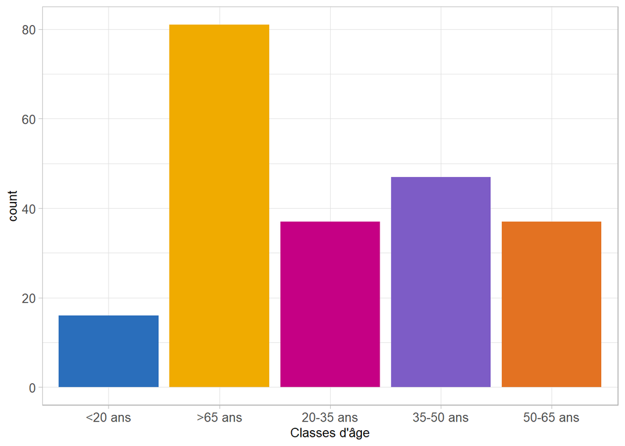

## Variables continues tronquées : population des phoques

- Variable *continue* : on va surement devoir *discretiser*
- Qui est limitée à 0
- Avec beaucoup de non réponse

Challenges techniques :

- Transformer la variable `chr` en variable `int`
- On va utiliser la population totale

**Q4 : Tabulez la population**

```r
remplacement_phoques_1 = function(x_){
#' Cette fonction donne une indication sur la connaissance (oui ou non) de la population de phoque
#' @param x_ une chaine de caractères


  return(grepl("non", str_to_lower(x_)))
}


remplacement_phoques_population = function(x_, option = "max"){

#' Extraction et classification des nombres liés aux populations de phoques
#'
#' Cette fonction analyse une chaîne de caractères pour extraire des nombres
#' (représentant des populations de phoques) et les classifier en différentes catégories
#' (`Beaucoup`, `Centaines`, `Milliers`, `Quelques uns`, etc.).
#'
#' @param x_ Une chaîne de caractères contenant une estimation de population (peut inclure des chiffres, des mots ou des expressions variées).
#' @param option Une option définissant si l'on souhaite récupérer la valeur minimale ou maximale
#' dans le cas de plages numériques (`"min"` ou `"max"`). Par défaut `"max"`.
#' @return Une valeur numérique si un chiffre est détecté, ou une catégorie (`"Beaucoup"`, `"Centaines"`, `"Milliers"`, `"Quelques uns"`, `"Non"`, etc.).



  # Approche par regex :
  potential_number = x_ %>%
    gsub(" ", "", .)%>%
    str_extract_all(.,"\\d+\\.?\\d*")%>%
    unlist()%>%
    as.numeric()
  # On repère les chiffres :
  # \\d+ repère un chiffre ou plusieurs
  # \\.? repère un point décimal
  # \\d* prent les 0

  # Ensuite on vérifie s'il y a des "-" ou des "/"

  tiret_barre = grepl("[-/]", x_)

  # Message d'erreur si l'option n'est pas bien spécifiée
  if(!(str_to_lower(option) %in% c("min", "max"))){
    stop("Error : option is ill picked")
  }

    # Enfin, on prend les "beaucoup" en compte :

  if(x_ %in% c(startsWith(str_to_lower(x_), "beauco"),
              'Bcp', 'Non beaucoup', 'Pas du tout (beaucoup)')){
    return("Beaucoup")
  }else if(is_empty(potential_number)){
    if(startsWith(str_to_lower(x_), 'oui')){
      return('Oui')
    }else if(grepl("centai", str_to_lower(x_))){
      return('Centaines')
    }else if(grepl('milli', str_to_lower(x_))){
      return('Milliers')
    }else if(grepl('un', str_to_lower(x_))){
      return('Quelques uns')
    }else{
      return('Non')
    }
  }else{
    if(tiret_barre){
      if(length(potential_number)>1){
        if(option=='min'){
          return(min(potential_number))
        }else if(option=="max"){
          return(max(potential_number))
        }
      }else{
        return(as.numeric(potential_number))
      }
    }else{
      return(sum(as.numeric(potential_number)))
    }
  }
}


#for(i in 1:nrow(data_)){
# print(paste(data_[i, 'q2_pop_phoques'],
#       remplacement(data_[i,'q2_pop_phoques'], option = "max")))
#}

data_ = data_ %>%
  mutate(clean_pop_yes_no = sapply(q2_pop_phoques, remplacement_phoques_1),
         clean_pop_max = sapply(q2_pop_phoques, remplacement_phoques_population))
```

## Variables catégorielles ordinales : professions

```r
t(table(data_$profession))# Pour voir les fréquences
```

```
##
##        Agence immobilier Agent public Agriculteur (à préciser) Aide à domicile
##   [1,]                 1           20                        3               1
##
##        Aide soignante Archéologue Assistante à domicile Cadre Cadre supérieur
##   [1,]              1           1                     1     1               3
##
##        Chômage Collégien Commerçant (préciser) Cuisine
##   [1,]       1         1                    13       1
##
##        Dessinateur en bureau d'étude Élève Élèves Employé Employee medical
##   [1,]                             1     1      2      26                1
##
##        Enseignante Entrepreneur indépendant Entreprise/tourisme (à préciser)
##   [1,]           1                        1                                1
##
##        Etudiant Étudiant Étudiant college Etudiante Étudiante Étudiantes
##   [1,]        1        5                1         2         2          1
##
##        Famille d'accueil Femme au foyer Foyer d’enfants Gérant de restaurant
##   [1,]                 1              1               1                    1
##
##        Infirmiere Infirmière
##   [1,]          1          1
##
##        Intermittente du spectacle + boutique d'ésortérisme Mairie
##   [1,]                                                   1      1
##
##        Maîtresse d'école Mécanicien Medical Non Ouvrier Ouvrier agricole
##   [1,]                 1          1       1   1       6                1
##
##        Pas demandé Pêcheur (préciser) Photographe Prof Professeur
##   [1,]           1                  2           1    4          1
##
##        Réceptionniste en hôtellerie Recruteur de donateurs pour association
##   [1,]                            1                                       1
##
##        Restauration/hôtellerie Retraite Retraité Retraité militaire
##   [1,]                      12       37       32                  1
##
##        Retraité pêcheurs Retraité/ avant aide soignante Retraitée Retraites
##   [1,]                 1                              1         1         1
##
##        Rien Sans Sans emploi Tabac Traducteur
##   [1,]    1    1           1     1          1
##
##        Travail avec des enfants handicapés Usine
##   [1,]                                   1     2
```

On a encore des problèmes d’encodage : je vous laisse y penser

- Trouvez les dénominations en CSP les plus pertinentes
- Regroupez les personnes dans la bonne CSP en :
  - Modifiant la fonction `remplacement()`
  - Et en attribuant les CSP à une nouvelle variable

On peut utiliser deux variables :

- Une variable de “haut” niveau de classification
- Une de “bas” niveau : plus de détails

On peut utiliser un prétraitement des données et la fonction `startsWith(x, prefix)` pour rassembler tout ce qui commencerait par la même racine

**Q5 : Utilisez `startsWith()` pour compléter la fonction suivante et rédigez la documentation**

```r
csp_questionnaire = c("Entreprise/tourisme", "Restauration/hôtellerie" , "Agriculteur (à préciser)", "Pêcheur (préciser)","Commerçant (préciser)", "Agent public",
                      "Cadre supérieur", "Employé", "Ouvrier")


remplacement_professions = function(x_){

#' Classification des professions à partir d'un questionnaire
#'


  x = x_%>%
    str_to_lower()%>%
    gsub("é", "e", .)%>%
    gsub("è", "e", .)

  if(x %in% c('agriculteur (à preciser)')){
    return("Agriculteur exploitant")
  }else if(startsWith(x, "employ") | x %in% c('aide à domicile',
                                              'aide soignante', 'assistante à domicile',
                                              "famille d'accueil", "tabac", "medical",
                                              "recruteur de donateurs pour association")){
    return("Employé.e")
  }else if(x %in% c('sans', 'rien', 'sans emploi', 'chômeur','chômage', 'non', "femme au foyer")){

  # COMPLETER L'EXPRESSION

    return('Sans activité professionelle (hors retraite)')
  }else if(startsWith(x, 'retrait')){
    return('Retraité.e')
  }else if(startsWith(x, 'ouvrier') | x %in% c('mecanicien', 'usine')){
    return("Ouvrier")
  }else if(startsWith(x, 'foyer') | x %in% c("infirmiere", "maîtresse d'ecole", 'enseignante', 'professeur', 'prof', "foyer d'enfants", "travail avec des enfants handicapes")){
    return('Professions intermédiaires')
  }else if(startsWith(x, 'cadr') | startsWith(x, 'intermittente') | x %in% c('traducteur', "archeologue", "dessinateur en bureau d'etude", 'photographe', "agence immobilier") ){
    return("Cadres et professions intellectuelles supérieures")
  # Catégories du questionnaire
  }else if(x %in% c('gerant de restaurant', 'receptionniste en hôtellerie', 'restauration/hôtellerie', "cuisine")){
    return("Restauration/hôtellerie")
  }else if(startsWith(x, "entrepr") | startsWith(x, "commerçant")){
    return("Artisans, commerçants, chefs d'entreprise")
  }else if(x %in% c('agent public', 'mairie')){
    return('Agent public')
  }else{
    return(x_)
  }

}
```

## Variables catégorielles non ordonnées (nominales) : nom des phoques

Ici, on va adopter la même approche par fonction de `remplacement_()`

```r
table(data_$q1_nom_phoques)
```

```
##
##                                 Gris                   Gris et veau marin
##                                    1                                    1
##                 Gris et veaux marins                             Les deux
##                                    1                                    1
##                                  Nln                                   Nn
##                                    1                                    2
##                                  Nob                                  non
##                                    1                                    1
##                                  Non                                  Oui
##                                  136                                   47
##        Oui (manque les phoques gris)                         Oui les deux
##                                    1                                    2
##                      Oui phoque gris OUI phoque gris et phoque veau-marin
##                                    1                                    1
##                    Oui plus ou moins                       Oui veau-marin
##                                    1                                    1
##                          Pas de tout                          Phoque gris
##                                    1                                    1
##                 Phoque gris et blanc                Phoque veau-marin oui
##                                    1                                    1
##                         Phoques gris                             Touriste
##                                    1                                    1
##                             Vaumarin                           Veau-marin
##                                    1                                    2
##          Veau-marin et phoque commun                           Veau marin
##                                    1                                    5
##             Veau marin , phoque gris                 Veau marin et phoque
##                                    1                                    1
##         Veaux-marins et phoques gris
##                                    1
```

On va prendre comme réponses possible : `oui`, `non`, `Partiel: veau marin` et `Partiel: phoque gris`

**Question 6 : faites une fonction de `remplacement` en utilisant ce qu’on a vu**

## Variables catégorielles nominales multiples: avis sur les phoques

La différence ici, c’est que plusieurs choix sont possibles

```r
# Trouver toutes les phrases possibles

phrases_ = c() # Initier un stock de phrases vide

for(row_ in 1:nrow(data_)){ # Pour chaque individu
  candidate_ =  unlist(# On enlève la structure de liste
    strsplit(as.character(data_[row_, "q6_avis"]), # qui résulte de la séparation de chaque réponse
             ", ") # autour de la virgule
    )
  for(element_ in candidate_){ # On regarde pour chaque phrase cnadidate
    if(!(element_ %in% phrases_)){ # Si elle a déja été dite
      phrases_ = c(phrases_, element_) # Sinon, on l'ajoute
    }
  }
}
# Imprimer les 15 premières phrases
phrases_[1:15]
```

```
##  [1] "Il faut laisser la nature évoluer librement"
##  [2] "La surfréquentation peut générer des dérangements pour la nature"
##  [3] "Les conflits entre les humains et les phoques augmentent"
##  [4] "Les phoques font partie du patrimoine du territoire"
##  [5] "Il y a trop de phoques veau-marin"
##  [6] "Il y a trop de phoques gris"
##  [7] "Il ne faut pas que le nombre de phoque augmente plus"
##  [8] "Les phoques mangent trop de poissons"
##  [9] "Les phoques représentent une opportunité économique pour le territoire"
## [10] "Les phoques représentent une menace économique pour le territoire"
## [11] "Il faudrait un groupe de travail local sur les interactions avec les phoques"
## [12] "Il faudrait plus de panneaux d’informations sur les phoques"
## [13] "Il faudrait des barrières pour empêcher de déranger les phoques"
## [14] "Il faudrait un centre d’information sur les phoques"
## [15] "Visites guide nature m"
```

- Ensuite, on fait ce qu’on appelle du one hot encoding , c’est à dire que l’on:
  - Transforme chaque affirmation en une variable
  - Qui prend la valeur 0 si absente, 1 si présente
  - Permet de numériser les variables *catégorielles* sans imposer d’ordre

```r
data_ = data_ %>%
  mutate(ID = seq(1:nrow(data_))) # On donne un identifiant à chaque individu statistique

# On crée une table d'occurence vide
table_occurrences <- matrix(0,
                            nrow = nrow(data_),
                            ncol = length(phrases_possibles),
                            dimnames = list(seq(1:nrow(data_)),
                                             phrases_possibles)) # Nomme les dimensions

# Remplir le tableau avec les occurrences
for (i in 1:nrow(data_)) {
  phrases_ = unlist(                            # On enlève la structure de liste
    strsplit(as.character(data_[i, "q6_avis"]), # qui résulte de la séparation de chaque réponse
             ", ")                              # autour de la virgule
    )
  for (phrase in phrases_) {                    # Pour chaque phrase exprimée,
    if (phrase %in% phrases_possibles) {        # si elle est dite,
      table_occurrences[i, phrase] <- table_occurrences[i, phrase] + 1 # on encode
    }
  }
}
```

## Variables catégorielles nominales multiples : questions sur les phoques

On fait la même chose pour la question sur les phoques

```r
phrases_ = c() # Initier un stock de phrases vide

for(row_ in 1:nrow(data_)){ # Pour chaque individu
  candidate_ =  unlist(# On enlève la structure de liste
    strsplit(as.character(data_[row_, "q5_classe_phoque"]), # qui résulte de la séparation de chaque réponse
             ", ") # autour de la virgule
    )
  for(element_ in candidate_){ # On regarde pour chaque phrase cnadidate
    if(!(element_ %in% phrases_)){ # Si elle a déja été dite
      phrases_ = c(phrases_, element_) # Sinon, on l'ajoute
    }
  }
}

phrases_possibles = c("Un animal sympathique et paisible", "Une espèce invasive et nuisible",
                      "Un concurrent pour les activités humaines", "Une espèce menacée",
                      "Un prédateur supérieur"
                      )

data_ = data_ %>%
  mutate(identifier = seq(1:nrow(data_))) # On donne un identifiant à chaque individu statistique


# On crée une table d'occurence vide
table_occurrences <- matrix(0,
                            nrow = nrow(data_),
                            ncol = length(phrases_possibles),
                             dimnames = list(seq(1:nrow(data_)),
                                             phrases_possibles)) # Pour stocker un identifiant

# Remplir le tableau avec les occurrences
for (i in 1:nrow(data_)) {
  phrases_ = unlist(# On enlève la structure de liste
    strsplit(as.character(data_[i, "q5_classe_phoque"]), # qui résulte de la séparation de chaque réponse
             ", ") # autour de la virgule
    )
  for (phrase in phrases_) {
    if (phrase %in% phrases_possibles) { # si elle est dite,
      table_occurrences[i, phrase] <- table_occurrences[i, phrase] + 1
    }
  }
}
```

## Variables catégorielles nominales multiples : loisirs

- Il y a beaucoup trop de réponses uniques (64)
- Il faut revenir aux résultats du questionnaire, et traiter notamment les réponses collées (variables catégorielles multiples)
- On refait du one hot encoding

**Q7 : Convertir la matrice en dataframe pour une meilleure lisibilité et changez les noms des colonnes avec `clean`**

```r
# I. On doit cleaner les données pour bien pouvoir les isoler : on supprime ce qu'il se passe entre parenthèse pour pouvoir séparer les entités par l'usage de la virgule
data_loc = data_ %>%
  select(loisir)

data_loc= data_loc %>%
  mutate(loisir_easy = gsub("\\s*\\(.*?\\)", '', loisir))%>%
  mutate(loisir_easy = gsub(" ", "", loisir_easy))%>%
  mutate(loisir_easy = str_to_lower(loisir_easy))



phrases_possibles = c("Pêche):", "Chasse", "Voile", "vélo", "natation",
                      "Planceàvoile", "Paddle",  "Kayak/canoë", "Kitesurf", "Equitation", "Wingfoil",
                      "Promenade", "Marche", "Naturaliste")
phrases_possibles = str_to_lower(phrases_possibles)

# II. On crée une table d'occurence vide
table_occurrences <- matrix(0,
                            nrow = nrow(data_),
                            ncol = length(phrases_possibles) +1, # On ajoute une case pour prendre en compte les cas "Autres"
                            dimnames = list(seq(1:nrow(data_)),
                                             c(phrases_possibles, "Autre"))) # Pour stocker un identifiant




#III. Remplir le tableau avec les occurrences
for (i in 1:nrow(data_)) {
  phrases_ =
    unlist(# On enlève la structure de liste
    strsplit(as.character(data_loc[i, "loisir_easy"]), # qui résulte de la séparation de chaque réponse
             ",") # autour de la virgule
    )
  for (phrase in phrases_) {
    if (phrase %in% phrases_possibles) { # si elle est dite,
      table_occurrences[i, phrase] <- table_occurrences[i, phrase] + 1
    }else{
      table_occurrences[i, "Autre"] = table_occurrences[i, "Autre"] +1
    }
  }
}


# Q7 : Convertir la matrice en dataframe pour une meilleure lisibilité
```

## Synthèse et nettoyage final

On merge tout et on sélectionne les données propres

**Q8 : utilisez le pipe operator (%>%) pour sélectionner les colonnes de la full_data et récupérer les colonnes qui ont le nom `clean` avec `grepl`**

```r
full_data = left_join(data_, table_phoques, by = 'ID')
full_data = left_join(full_data, table_occurrences_df, by = 'ID')
#full_data = left_join(full_data, table_loisir, by = "ID")

data_clean = full_data %>%
  select(c('date', 'lieu', 'genre', 'classe_age',    # Les données déja propres
           colnames(full_data)[
             #ICI
             ]
           )
         )

colnames(data_clean) = gsub("clean_", "", colnames(data_clean))

write.xlsx(data_clean, here("data", "processed", "data_cleaned.xlsx"))
```

## Documentation

- Créez un fichier `.txt` ou `.md` qui détaille les données *brutes* et enregistrez le dans `/docs/README_rawdata.txt`
- Créez un fichier `.txt` ou `md` qui détaille les transformations appliquées aux données et les fonctions utilisées, et enregistrez le dans `/docs/REAME_datacleaning.txt`
- Updates le script `fonctions.R` avec les fonctions que l’on a utilisées : elles ne sont pas encore très modulaires ou beaucoup réutilisables, mais c’est un premier pas.